# NYPD Shooting Incident Data

Gabrielle Olinger

2026-02-26

```r
library(tidyverse)
library(lubridate)
```

## Motivation

Gun violence is a preventable public health crisis that affects communities across the United States. Over 46,000 people died by firearms in the US in 2023 – equivalent to an average of one death every 11 minutes [1]. Publicly available crime data allows researchers to study shooting incidents, reveal risk factors for gun violence, and help communities respond more effectively. Publicly available crime data support the creation of evidence-based policies. Studies that aim to understand the root causes of violence support long-term solutions.

## Importing Data

In this report, I evaluate shooting incident data collected in New York from 2006 to the end of 2025. This data is reviewed by the Office of Management Analysis and Planning before being published. Each instance is a shooting incident, and variables describing the incident include location, time, victim demographics, and offender demographics. The data is divided into three files – shooting incidents, shooting victims, and shooting offenders. This data can be joined using the unique incident key. The main data can be accessed via this webpage: https://catalog.data.gov/dataset/nypd-shootings.

```r
# In the week before submitting my project, data.gov changed how they were handling these files twice.
# In order to ensure my peers can knit this file, I uploaded a version of this data to my github
incidents_untidy = read_csv("https://raw.githubusercontent.com/gabbyoln/DTSA5301-Projects/refs/heads/main/data/Shootings_(2006-Present)_20260226.csv")
victims_untidy = read_csv("https://raw.githubusercontent.com/gabbyoln/DTSA5301-Projects/refs/heads/main/data/Shooting_Victims_(2006-Present)_20260226.csv")
```

## Tidying and Transforming Data

To understand what some of the variables represent, I downloaded the data dictionary available for this data set here (https://data.cityofnewyork.us/Public-Safety/NYPD-Shootings/98wc-x49t/about_data).

First I joined together the incident data with the victim data, and I removed any duplicate incidents.

```r
dat_untidy <- full_join(incidents_untidy, victims_untidy, by = 'INCIDENT_KEY')%>%
  distinct_at(vars(INCIDENT_KEY,VICTIM_ID), .keep_all = TRUE)
```

I changed the date variable to a date format and appropriate variables to a factor format. I also removed variables that are not of interest.

```r
dat <- dat_untidy %>%
  select(-c(INCIDENT_KEY, VICTIM_ID, OCCUR_TIME, PRECINCT, JURISDICTION_CODE, STAT_MURDER_FLG, X_COORD_CD, Y_COORD_CD, Latitude, Longitude)) %>%
  mutate_at(vars(BORO, LOC_OF_OCCUR_DESC, LOC_CLASSFCTN_DESC, LOCATION_DESC, VICTIM_AGE_GROUP, VICTIM_SEX, VICTIM_RACE), as.factor) %>%
    mutate(OCCUR_DATE = mdy(OCCUR_DATE)) %>%
    rename(DATE = 'OCCUR_DATE')

#head(dat)
```

Here I was trying to get a better understanding of the location data.

```r
levels(dat$LOC_OF_OCCUR_DESC)
```

```
## [1] "INSIDE"  "OUTSIDE"
```

```r
levels(dat$LOCATION_DESC)
```

```
##  [1] "ATM"                       "BANK"
##  [3] "BAR/NIGHT CLUB"            "BEAUTY/NAIL SALON"
##  [5] "CANDY STORE"               "CHAIN STORE"
##  [7] "CHECK CASH"                "CLOTHING BOUTIQUE"
##  [9] "COMMERCIAL BLDG"           "DEPT STORE"
## [11] "DOCTOR/DENTIST"            "DRUG STORE"
## [13] "DRY CLEANER/LAUNDRY"       "FACTORY/WAREHOUSE"
## [15] "FAST FOOD"                 "GAS STATION"
## [17] "GROCERY/BODEGA"            "GYM/FITNESS FACILITY"
## [19] "HOSPITAL"                  "HOTEL/MOTEL"
## [21] "JEWELRY STORE"             "LIQUOR STORE"
## [23] "LOAN COMPANY"              "MULTI DWELL - APT BUILD"
## [25] "MULTI DWELL - PUBLIC HOUS" "NONE"
## [27] "PHOTO/COPY STORE"          "PVT HOUSE"
## [29] "RESTAURANT/DINER"          "SCHOOL"
## [31] "SHOE STORE"                "SMALL MERCHANT"
## [33] "SOCIAL CLUB/POLICY LOCATI" "STORAGE FACILITY"
## [35] "STORE UNCLASSIFIED"        "SUPERMARKET"
## [37] "TELECOMM. STORE"           "VARIETY STORE"
## [39] "VIDEO STORE"
```

```r
levels(dat$LOC_CLASSFCTN_DESC)
```

```
##  [1] "COMMERCIAL"  "DWELLING"    "HOUSING"     "OTHER"       "PARKING LOT"
##  [6] "PLAYGROUND"  "STREET"      "TAXI/LIVERY" "TRANSIT"     "VEHICLE"
```

```r
summary(dat)
```

```
##       DATE                       BORO       LOC_OF_OCCUR_DESC
##  Min.   :2006-01-01   BRONX        : 8299   INSIDE : 4004
##  1st Qu.:2010-01-18   BROOKLYN     :11657   OUTSIDE:24742
##  Median :2014-07-20   MANHATTAN    : 3742   NA's   :    2
##  Mean   :2015-03-05   QUEENS       : 4293
##  3rd Qu.:2020-08-30   STATEN ISLAND:  755
##  Max.   :2025-12-31   NA's         :    2
##  NA's   :2
##   LOC_CLASSFCTN_DESC                   LOCATION_DESC   VICTIM_AGE_GROUP
##  STREET    :18806    MULTI DWELL - PUBLIC HOUS: 5016   25-44  :13160
##  HOUSING   : 5156    MULTI DWELL - APT BUILD  : 2778   18-24  :10390
##  DWELLING  : 2289    PVT HOUSE                :  922   <18    : 2968
##  COMMERCIAL: 1335    GROCERY/BODEGA           :  721   45-64  : 1964
##  PLAYGROUND:  405    BAR/NIGHT CLUB           :  692   65+    :  207
##  (Other)   :  721    (Other)                  : 1444   (Other):   58
##  NA's      :   36    NA's                     :17175   NA's   :    1
##     VICTIM_SEX                      VICTIM_RACE
##  FEMALE  : 2610   BLACK                   :20801
##  INTERSEX:    1   WHITE HISPANIC          : 4057
##  MALE    :26126   BLACK HISPANIC          : 2702
##  UNKNOWN :   10   WHITE                   :  687
##  NA's    :    1   ASIAN / PACIFIC ISLANDER:  424
##                   (Other)                 :   76
##                   NA's                    :    1
```

```r
dat <- dat %>%
  drop_na(DATE)%>%
  select(-c(LOCATION_DESC, LOC_OF_OCCUR_DESC))%>%
  rename(LOCATION = LOC_CLASSFCTN_DESC)

summary(dat)
```

```
##       DATE                       BORO             LOCATION     VICTIM_AGE_GROUP
##  Min.   :2006-01-01   BRONX        : 8299   STREET    :18806   <18    : 2968
##  1st Qu.:2010-01-18   BROOKLYN     :11657   HOUSING   : 5156   1022   :    1
##  Median :2014-07-20   MANHATTAN    : 3742   DWELLING  : 2289   18-24  :10390
##  Mean   :2015-03-05   QUEENS       : 4293   COMMERCIAL: 1335   25-44  :13159
##  3rd Qu.:2020-08-30   STATEN ISLAND:  755   PLAYGROUND:  405   45-64  : 1964
##  Max.   :2025-12-31                         (Other)   :  721   65+    :  207
##                                             NA's      :   34   UNKNOWN:   57
##     VICTIM_SEX                            VICTIM_RACE
##  FEMALE  : 2610   AMERICAN INDIAN/ALASKAN NATIVE:   13
##  INTERSEX:    1   ASIAN / PACIFIC ISLANDER      :  424
##  MALE    :26125   BLACK                         :20801
##  UNKNOWN :   10   BLACK HISPANIC                : 2701
##                   UNKNOWN                       :   63
##                   WHITE                         :  687
##                   WHITE HISPANIC                : 4057
```

The only remaining missing data is location. Later when I look at incidents based on location, I include only incidents where location data is provided.

## Visualizing Data

I was first interested in the number of shootings over time depending on the borough.

```r
# global presets for ggplot
my_theme <- theme_minimal()+
  theme(plot.title = element_text(size = 12))
theme_set(my_theme)
```

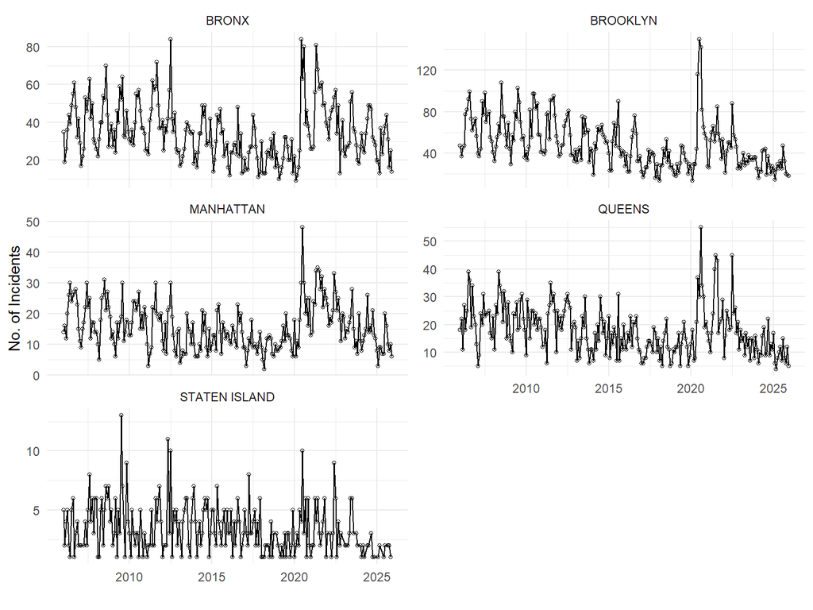

```r
# first transform the data appropriately
time_series <- dat %>%
  select(DATE, BORO) %>%
  # this counts incidents by month instead of day
  group_by(year_month = floor_date(DATE, 'month'), BORO) %>%
  summarize(incidents = n()) %>%
  ungroup()

# visualize
time_series %>%
  ggplot() +
  geom_line(aes(x = year_month, y = incidents),linewidth = .5)+
  geom_point(aes(x = year_month, y = incidents), size = 1, pch = 1)+
  facet_wrap(~BORO, scales = 'free_y', nrow = 3)+
  labs(x = "", y = 'No. of Incidents')
```

Some of the boroughs saw a surge of shooting incidents around 2020. The following code is used to determine exactly where those maxima are:

```r
boros <- unique(time_series$BORO)
for (boro in boros){
  temp <- time_series %>%
    filter(BORO == boro)%>%
    slice_max(incidents)
  print(temp)
}
```

```
## # A tibble: 2 × 3
##   year_month BORO  incidents
##   <date>     <fct>     <int>
## 1 2012-07-01 BRONX        84
## 2 2020-06-01 BRONX        84
## # A tibble: 1 × 3
##   year_month BORO     incidents
##   <date>     <fct>        <int>
## 1 2020-07-01 BROOKLYN       150
## # A tibble: 1 × 3
##   year_month BORO      incidents
##   <date>     <fct>         <int>
## 1 2020-07-01 MANHATTAN        48
## # A tibble: 1 × 3
##   year_month BORO   incidents
##   <date>     <fct>      <int>
## 1 2020-08-01 QUEENS        55
## # A tibble: 1 × 3
##   year_month BORO          incidents
##   <date>     <fct>             <int>
## 1 2009-07-01 STATEN ISLAND        13
```

#### **Analysis**

I was interested in whether the demographics of victims differed during this period of increased shootings in Brooklyn. I compared victim demographics in Brooklyn across two periods of time: the summer of 2020 (June-August) and Jan. 2006 through May 2020.

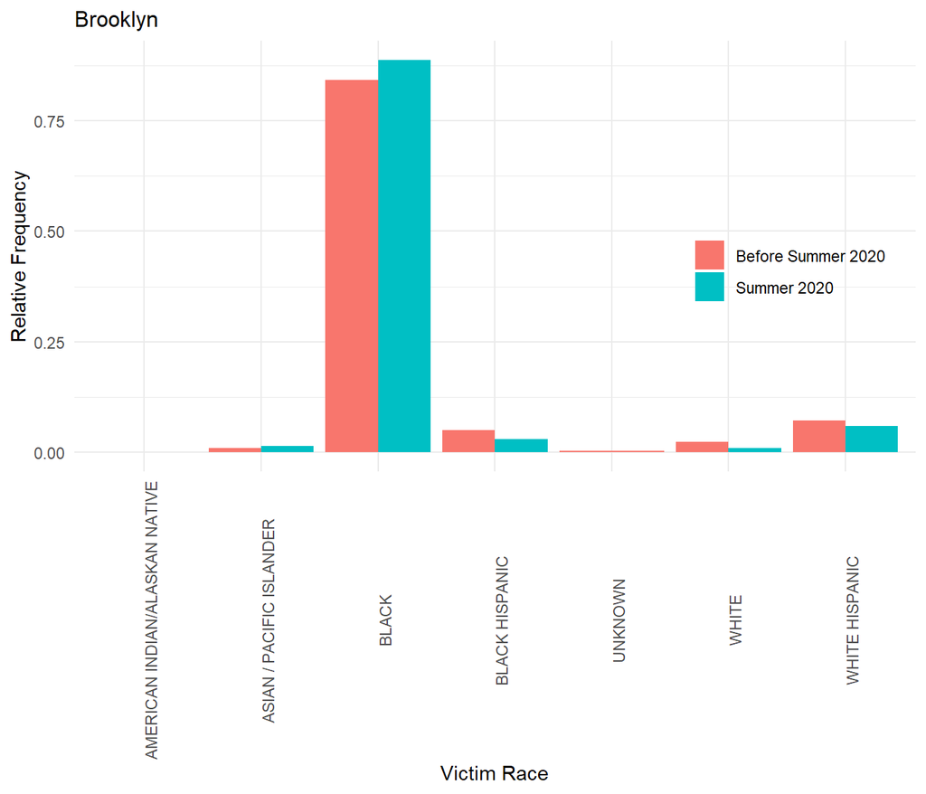

```r
# selecting two datasets based off of two different time periods in Brooklyn
brook_summer <- dat %>%
  filter(BORO == 'BROOKLYN', DATE >= '2020-06-01', DATE < '2020-09-01')
brook_other <- dat %>%
  filter(BORO == 'BROOKLYN', DATE >= '2006-01-01',DATE < '2020-06-01')

# obtaining relative frequencies of victim races
race_summer <- brook_summer %>%
  count(VICTIM_RACE) %>%
  mutate(relative_freq = n/sum(n), period = 'Summer 2020')

race_other <- brook_other %>%
  count(VICTIM_RACE) %>%
  mutate(relative_freq = n/sum(n), period = 'Before Summer 2020')

#visualizing
full_join(race_summer, race_other) %>%
  ggplot(aes(x = VICTIM_RACE, relative_freq, fill = period))+
  geom_col(position = position_dodge())+
  labs(x = 'Victim Race', y = 'Relative Frequency', title = 'Brooklyn', fill = '')+
  theme(axis.text.x = element_text(angle = 90), legend.position  = c(0.85,0.5))
```

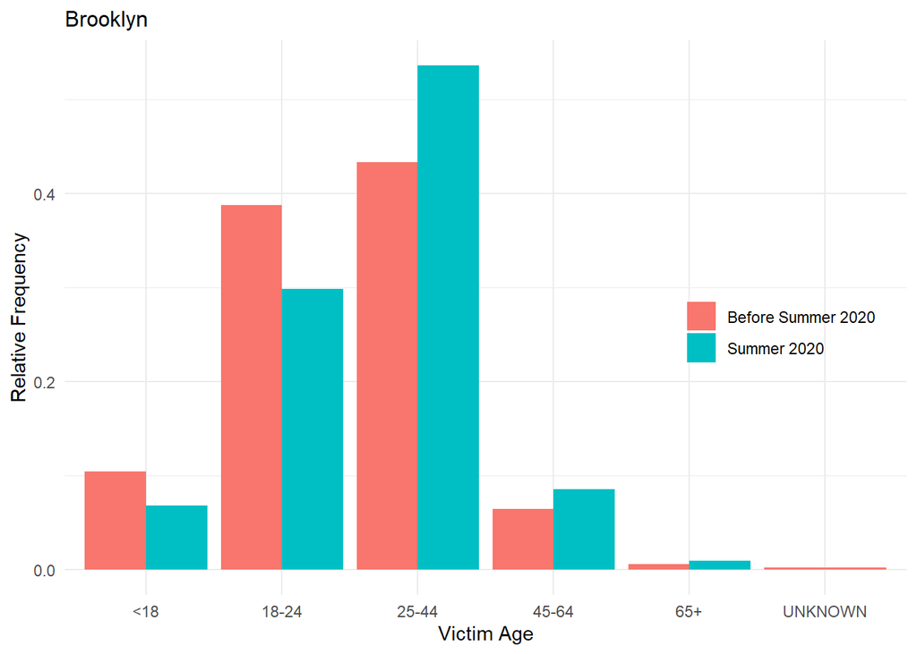

```r
# obtaining relative frequencies of victim races
age_summer <- brook_summer %>%
  count(VICTIM_AGE_GROUP) %>%
  mutate(relative_freq = n/sum(n), period = 'Summer 2020')

age_other <- brook_other %>%
  count(VICTIM_AGE_GROUP) %>%
  mutate(relative_freq = n/sum(n), period = 'Before Summer 2020')

# visualizing
full_join(age_summer, age_other) %>% ggplot(aes(x = VICTIM_AGE_GROUP, relative_freq, fill = period))+
  geom_col(position = position_dodge())+
  labs(x = 'Victim Age', y = 'Relative Frequency', fill = '', title = 'Brooklyn')+
  theme(axis.text.x = element_text(angle = 0), legend.position = c(0.85,0.5))
```

I also wanted to visualize the different locations of shootings during Summer 2020 in Brooklyn. I exclude incidents with missing values.

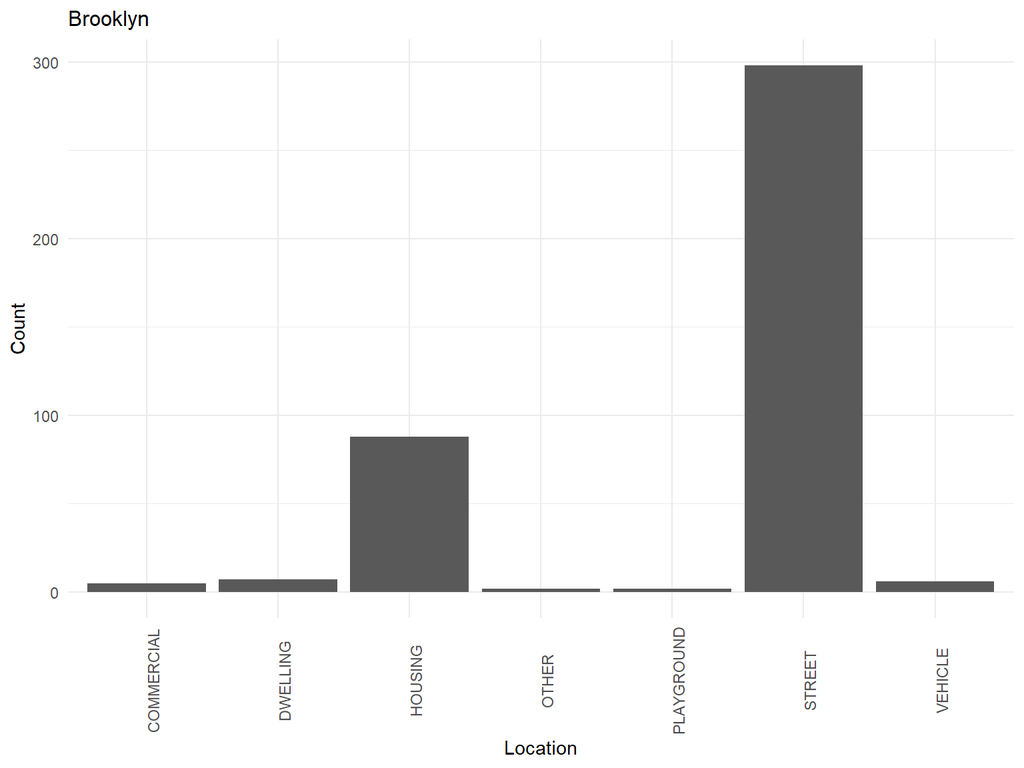

```r
# counting locations
loc_summer <- brook_summer %>%
  count(LOCATION) %>%
  drop_na()

# visualizing
loc_summer %>% ggplot()+
  geom_col(aes(x = LOCATION, y = n))+
  theme(axis.text.x = element_text(angle = 90))+
  labs(x = 'Location', y = 'Count', title = 'Brooklyn')
```

#### **Analysis**

The first two bar graphs examine the victim demographics of shootings that occurred (i) in Summer 2020 (June-August) and (ii) prior to this summer, between January 2006 and May 2020. Victim race did not differ significantly, with Summer 2020 seeing a slightly higher proportion of Black victims – and a slightly lower proportion of white victims – compared to previous years. Shooting incidents in Summer 2020 also had a higher proportion of adult victims, ages 25 and above and lower proportion of younger victims, ages 24 and below. This raises questions about how COVID-19 shutdowns affected youth and whether online schooling and quarantine resulted in fewer young people being exposed to certain forms of violence. The third bar graph shows that the highest reported location of shooting incidents in Summer 2020 in Brooklyn was the street. This is consistent with the trend in the overall data that most shootings occur outside.

## Question of Interest

The time series of shooting incidents in Brooklyn is intriguing. There is both cyclical variation and a sudden rise in shootings Summer 2020. Because the majority of shootings occur outside, my hypothesis is that higher temperatures may correlate with increased shootings; people tend to be outside when it’s warmer – and more people outside may lead to more conflict. In order to evaluate the sudden spike in shootings, context is important. Summer 2020 was the first summer following the COVID-19 shutdowns, a period defined by far-reaching disruptions, including a sharp rise in unemployment. This leads me to the following question:

**How do shooting incident trends compare with trends in unemployment and temperature?**

### Unemployment data

In order to address this question, I need to upload supplementary unemployment data (webpage: https://catalog.data.gov/dataset/local-area-unemployment-statistics-beginning-1976).

This data is collected by the Local Area Unemployment Statistics program for the New York civilian labor force. This includes individuals ages 16 and up and does not include military, prison inmate, or other institutional populations. This data provides several measures of employment, including unemployment rate. Data is provided for several levels of granularity – including on the county level as well as for New York State and New York City.

```r
unemp_untidy <- read_csv("https://data.ny.gov/api/views/5hyu-bdh8/rows.csv?accessType=DOWNLOAD")
```

In order to tidy this data, I need to adjust the formatting of the date. Additionally, this dataset has counties, whereas the shooting data has boroughs. In order to properly match the datasets, I used the following information (obtained from https://portal.311.nyc.gov/article/?kanumber=KA-02877):

| Borough | County |
| --- | --- |
| Bronx | Bronx County |
| Brooklyn | Kings County |
| Manhattan | New York County |
| Queens | Queens County |
| Staten Island | Richmond County |

```r
# reformatting the date variables to match the other data set
unemp <- unemp_untidy %>%
  unite('year_month', Year, Month, sep = '-')
unemp$year_month <- paste(unemp$year_month, "-01", sep = "")
unemp$year_month <- ymd(unemp$year_month)

# selecting the variables I need
unemp <- unemp %>%
  rename(unemployment_rate = `Unemployment Rate`) %>%
  select(c(year_month, Area, unemployment_rate)) %>%
# remapping counties to boroughs
  mutate(Area = case_when(
    Area == 'Bronx County' ~ "BRONX",
    Area == 'Kings County' ~ 'BROOKLYN',
    Area == 'New York County' ~ 'MANHATTAN',
    Area == 'Queens County' ~ 'QUEENS',
    Area == 'Richmond County' ~ 'STATEN ISLAND',
    TRUE ~ Area
  )) %>%
# selecting only boroughs of interest and renaming the column
  filter(Area %in% boros) %>%
  rename(BORO = 'Area') %>%
  mutate(BORO = as.factor(BORO))
```

```r
summary(unemp)
```

```
##    year_month                    BORO     unemployment_rate
##  Min.   :1990-01-01   BRONX        :431   Min.   : 3.000
##  1st Qu.:1998-12-01   BROOKLYN     :431   1st Qu.: 5.200
##  Median :2007-12-01   MANHATTAN    :431   Median : 7.200
##  Mean   :2007-12-01   QUEENS       :431   Mean   : 7.398
##  3rd Qu.:2016-12-01   STATEN ISLAND:431   3rd Qu.: 9.050
##  Max.   :2025-12-01                       Max.   :26.500
```

### Climate Data

Below I imported county-level precipitation and temperature data – which dates as far back as 1895 – provided by National Centers for Environmental Information (NCEI). Temperature data is provided as a monthly average and in degrees Farenheit. The data was originally accessed via this web tool: https://data.timesrecordnews.com/weather-data/bronx-county-new-york/36005/2025-12-01/table/.

```r
bronx_climate <- read_csv("https://raw.githubusercontent.com/gabbyoln/DTSA5301-Projects/refs/heads/main/data/NYTemps%20-%20Bronx.csv")
brook_climate <- read_csv("https://raw.githubusercontent.com/gabbyoln/DTSA5301-Projects/refs/heads/main/data/NYTemps%20-%20Brooklyn.csv")
man_climate <- read_csv("https://raw.githubusercontent.com/gabbyoln/DTSA5301-Projects/refs/heads/main/data/NYTemps%20-%20Manhattan.csv")
queens_climate <- read_csv("https://raw.githubusercontent.com/gabbyoln/DTSA5301-Projects/refs/heads/main/data/NYTemps%20-%20Queens.csv")
staten_climate <- read_csv("https://raw.githubusercontent.com/gabbyoln/DTSA5301-Projects/refs/heads/main/data/NYTemps%20-%20Staten%20Island.csv")
```

```r
# add column for borough and then join the data together
brook_climate <- brook_climate %>%
  mutate(BORO = 'BROOKLYN')
bronx_climate <- bronx_climate %>%
  mutate(BORO = 'BRONX')
man_climate <- man_climate %>%
  mutate(BORO = 'MANHATTAN')
queens_climate <- queens_climate %>%
  mutate(BORO = 'QUEENS')
staten_climate <- staten_climate %>%
  mutate(BORO = 'STATEN ISLAND')

climate <- bind_rows(brook_climate, bronx_climate) %>%
  bind_rows(man_climate) %>%
  bind_rows(queens_climate) %>%
  bind_rows(staten_climate)

# change the date format to match the time series
climate <- climate %>%
  mutate(BORO = as.factor(BORO)) %>%
  mutate(date = floor_date(my(date), 'month')) %>%
  rename(year_month = 'date')

summary(climate)
```

```
##    year_month            avg_temp       min_temp        max_temp
##  Min.   :1895-01-01   Min.   :17.8   Min.   : 7.60   Min.   :26.30
##  1st Qu.:1927-09-23   1st Qu.:38.7   1st Qu.:31.40   1st Qu.:46.00
##  Median :1960-06-16   Median :53.4   Median :44.30   Median :62.50
##  Mean   :1960-06-16   Mean   :53.3   Mean   :45.04   Mean   :61.56
##  3rd Qu.:1993-03-08   3rd Qu.:68.8   3rd Qu.:59.90   3rd Qu.:77.60
##  Max.   :2025-12-01   Max.   :81.2   Max.   :72.70   Max.   :90.70
##  precipitation               BORO
##  Min.   : 0.000   BRONX        :1572
##  1st Qu.: 2.430   BROOKLYN     :1572
##  Median : 3.525   MANHATTAN    :1572
##  Mean   : 3.790   QUEENS       :1572
##  3rd Qu.: 4.760   STATEN ISLAND:1572
##  Max.   :18.560
```

Then I joined the climate data and unemployment data with the original shooting incident data.

```r
# join the data and select variables of interest
time_series_full <- left_join(time_series, unemp, by = c('year_month', 'BORO')) %>%
  left_join(climate, by = c('year_month', 'BORO')) %>%
  select(-c(min_temp, max_temp, precipitation))
summary(time_series_full)
```

```
##    year_month                    BORO       incidents      unemployment_rate
##  Min.   :2006-01-01   BRONX        :240   Min.   :  1.00   Min.   : 3.000
##  1st Qu.:2010-12-01   BROOKLYN     :240   1st Qu.:  9.00   1st Qu.: 4.675
##  Median :2015-11-01   MANHATTAN    :240   Median : 20.00   Median : 6.000
##  Mean   :2015-11-18   QUEENS       :240   Mean   : 24.34   Mean   : 6.944
##  3rd Qu.:2020-11-01   STATEN ISLAND:221   3rd Qu.: 34.00   3rd Qu.: 8.700
##  Max.   :2025-12-01                       Max.   :150.00   Max.   :26.500
##                                                            NA's   :5
##     avg_temp
##  Min.   :22.70
##  1st Qu.:41.40
##  Median :56.10
##  Mean   :55.95
##  3rd Qu.:71.00
##  Max.   :81.20
##
```

```r
time_series_full %>% filter(is.na(unemployment_rate))
```

```
## # A tibble: 5 × 5
##   year_month BORO          incidents unemployment_rate avg_temp
##   <date>     <fct>             <int>             <dbl>    <dbl>
## 1 2025-10-01 BRONX                16                NA     58.5
## 2 2025-10-01 BROOKLYN             20                NA     59
## 3 2025-10-01 MANHATTAN             8                NA     58.7
## 4 2025-10-01 QUEENS                6                NA     58.5
## 5 2025-10-01 STATEN ISLAND         2                NA     58.6
```

For reasons unknown to me, unemployment data is missing for each borough in the month of October 2025. Below I compared the amount of shooting incidents to the unemployment rate and temperature over time in Brooklyn.

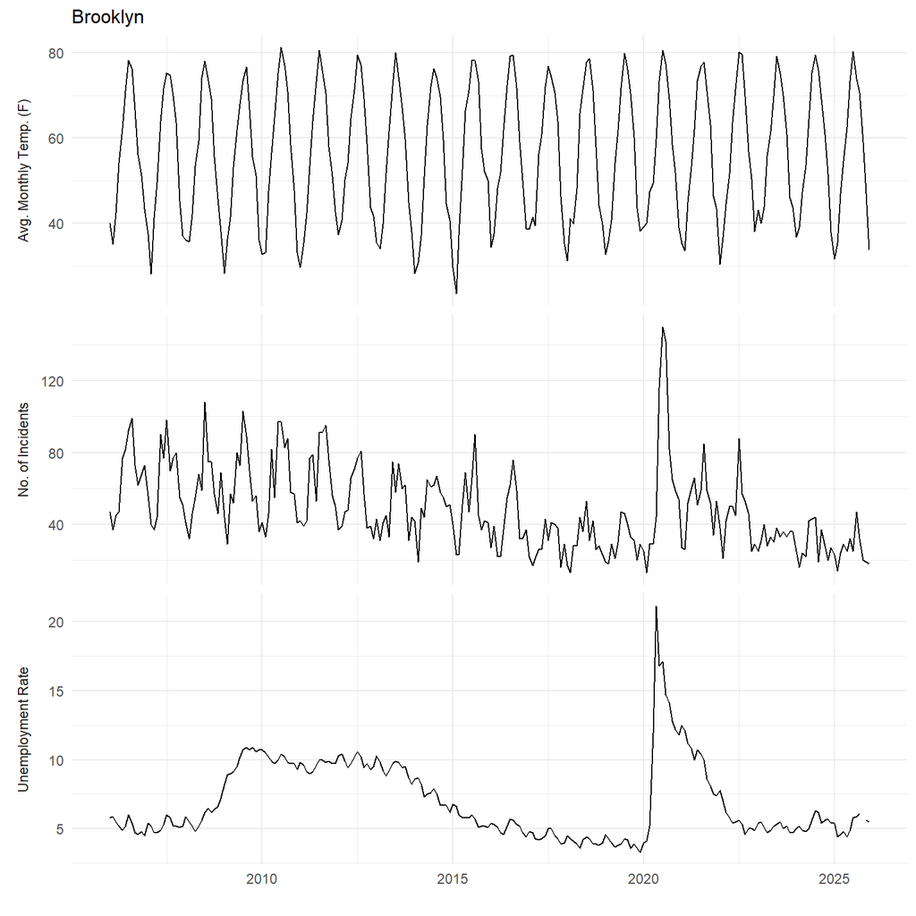

```r
brook_time_series <- time_series_full %>%
  filter(BORO == 'BROOKLYN')%>%
  pivot_longer(
    cols = c(incidents, unemployment_rate, avg_temp),
    names_to = 'variable',
    values_to = 'value'
  )

brook_time_series %>% ggplot()+
  geom_line(aes(x = year_month, y = value))+
  facet_wrap(~variable, scales = 'free_y', nrow = 3, strip.position = "left",
             labeller = as_labeller(c(avg_temp = "Avg. Monthly Temp. (F)",
                                      unemployment_rate = 'Unemployment Rate',
                                      incidents = 'No. of Incidents')))+
  labs(y = NULL, x = '', title = 'Brooklyn')+
  theme(strip.background = element_blank(),
        strip.placement = "outisde")
```

This figure shows that the major spike in shootings in Brooklyn does seem to coincide with a sudden surge of unemployment. It also seems that the there were similar reductions in both shootings and unemployment between 2010 and 2020. Additionally, seasonal variation in temperature also seem to coincide with shooting incidents, with high temperatures corresponding to local maxima in the shooting data time series.

## Model

I modeled 10 years of data – January 2015 through December 2024. The cut-off in 2024 is due to missing unemployment data in 2025, as mentioned above. I first evaluated if there is a linear relationship between unemployment and shooting incidents.

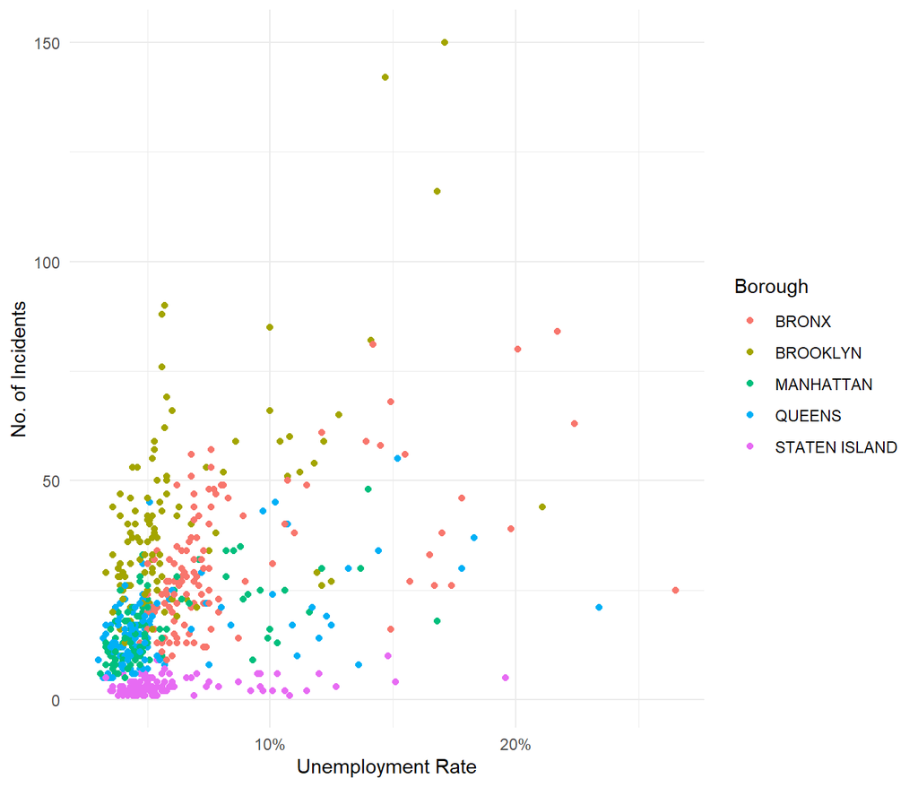

```r
model_data <- time_series_full %>%
  filter(year_month >= '2015-01-01' & year_month < '2025-01-01')


model_data %>% ggplot()+
  geom_point(aes(x = unemployment_rate, y = incidents, color = BORO))+
  labs(x = "Unemployment Rate", y = 'No. of Incidents', color = 'Borough')+
  scale_x_continuous(labels = scales::percent_format(scale = 1))
```

This figure shows that if there is a relationship between unemployment rate and shooting incidents, this relationship is likely unique to each of the five boroughs in New York. The boroughs would best be modeled separately, so I chose to focus on Brooklyn for the purposes of this report.

```r
brook_data <- model_data %>% filter(BORO == 'BROOKLYN')
mod <- lm(incidents~unemployment_rate, data = brook_data)
summary(mod)
```

```
##
## Call:
## lm(formula = incidents ~ unemployment_rate, data = brook_data)
##
## Residuals:
##     Min      1Q  Median      3Q     Max
## -60.523 -10.285  -1.973   7.236  64.842
##
## Coefficients:
##                   Estimate Std. Error t value Pr(>|t|)
## (Intercept)        14.3040     3.6551   3.913 0.000153 ***
## unemployment_rate   4.2758     0.5297   8.072 6.58e-13 ***
## ---
## Signif. codes:  0 '***' 0.001 '**' 0.01 '*' 0.05 '.' 0.1 ' ' 1
##
## Residual standard error: 18.02 on 118 degrees of freedom
## Multiple R-squared:  0.3557, Adjusted R-squared:  0.3503
## F-statistic: 65.15 on 1 and 118 DF,  p-value: 6.578e-13
```

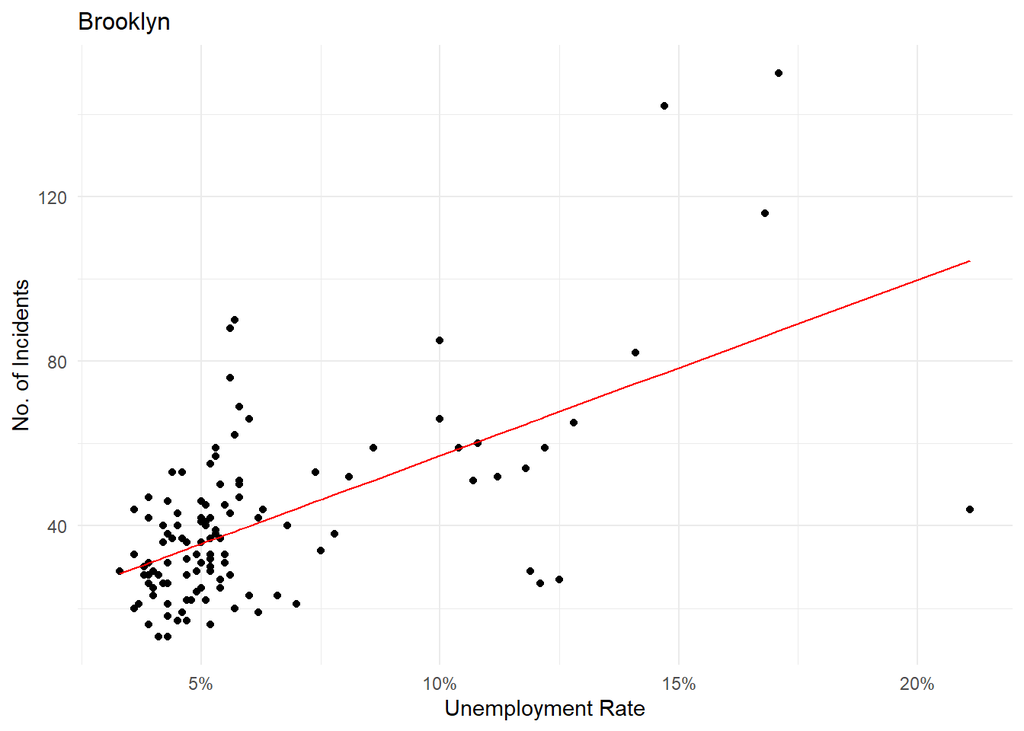

```r
brook_data %>% mutate(pred = predict(mod)) %>%
  ggplot()+
  geom_point(aes(x = unemployment_rate, y = incidents))+
  geom_line(aes(x = unemployment_rate, y = pred), color = 'red')+
  labs(x = "Unemployment Rate", y = 'No. of Incidents', title = 'Brooklyn')+
  scale_x_continuous(labels = scales::percent_format(scale = 1))
```

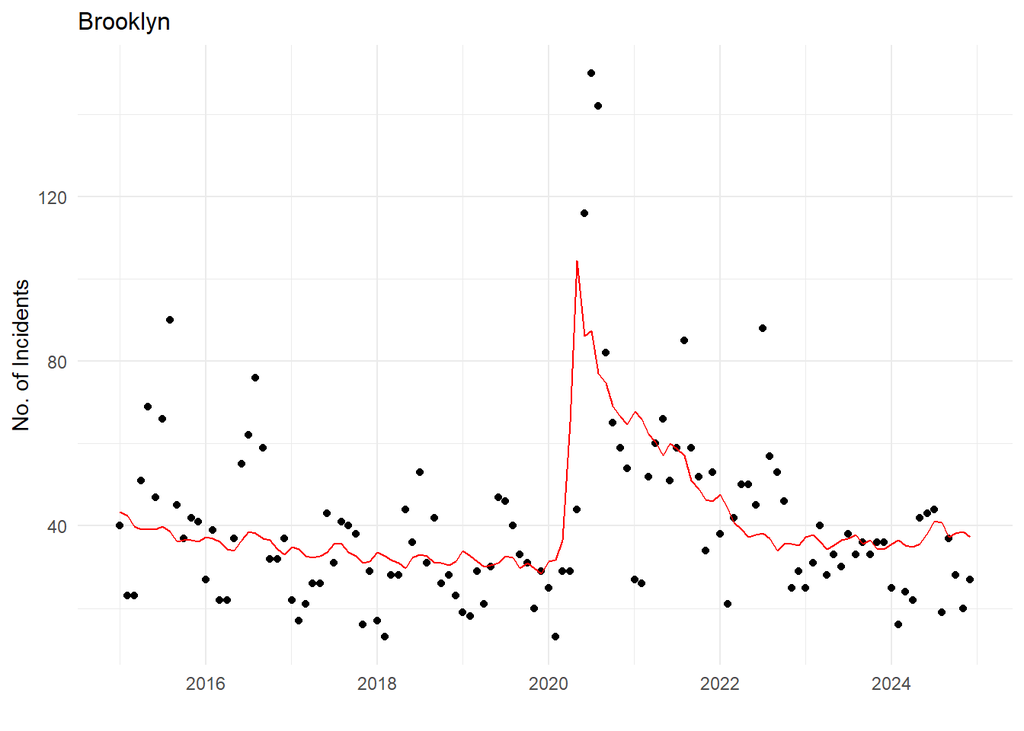

```r
brook_data %>% mutate(pred = predict(mod)) %>%
  ggplot()+
  geom_point(aes(x = year_month, y = incidents))+
  geom_line(aes(x = year_month, y = pred), color = 'red')+
  labs(x = '', y = 'No. of Incidents', title = 'Brooklyn')
```

Below shows the results of a model using both unemployment rate and temperature.

```r
mod <- lm(incidents ~ unemployment_rate+avg_temp, data = brook_data)
summary(mod)
```

```
##
## Call:
## lm(formula = incidents ~ unemployment_rate + avg_temp, data = brook_data)
##
## Residuals:
##     Min      1Q  Median      3Q     Max
## -56.939  -7.654  -0.648   6.944  53.206
##
## Coefficients:
##                    Estimate Std. Error t value Pr(>|t|)
## (Intercept)       -23.89419    5.33390  -4.480 1.75e-05 ***
## unemployment_rate   3.88404    0.42055   9.236 1.37e-15 ***
## avg_temp            0.71826    0.08437   8.514 6.62e-14 ***
## ---
## Signif. codes:  0 '***' 0.001 '**' 0.01 '*' 0.05 '.' 0.1 ' ' 1
##
## Residual standard error: 14.22 on 117 degrees of freedom
## Multiple R-squared:  0.6022, Adjusted R-squared:  0.5954
## F-statistic: 88.55 on 2 and 117 DF,  p-value: < 2.2e-16
```

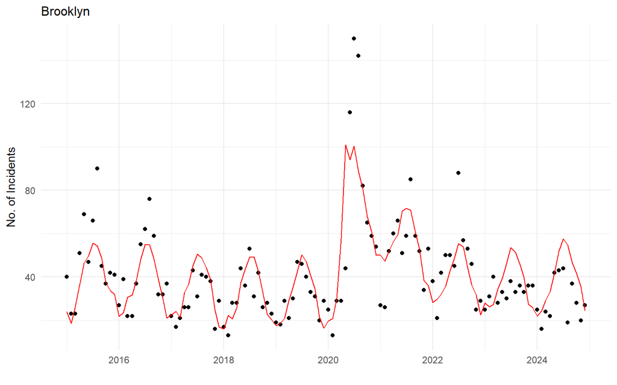

```r
brook_data %>% mutate(pred = predict(mod)) %>%
  ggplot()+
  geom_point(aes(x = year_month, y = incidents))+
  geom_line(aes(x = year_month, y= pred), color = 'red')+
  labs(x = '', y = 'No. of Incidents', title = 'Brooklyn')
```

#### **Analysis**

I created a simple linear model using unemployment rate as a single predictor, and this model is visualized in the first two scatterplots above. The relationship is not very linear, with unemployment explaining only 35.57% of the variation in shooting incidents.

I then employed a multiple linear regression model with two predictors: temperature and unemployment. This model performed better, with unemployment and temperature explaining 59.54% of the variation in shooting incidents. This improvement is shown in the figure above. The model struggles with extreme maxima, suggesting that there are additional factors contributing to periods of increasing shootings. Future studies could introduce predictors such as social factors (e.g. community cohesion or residential mobility), gun ownership, or additional measures of socioeconomic disadvantage (e.g. poverty rate or access to education).

## Bias

As with any crime data, there is risk of reporting bias. This analysis examines only shooting incidents that were reported. In some areas in the United States, as few as 12% of shooting incidents result in a 911 call [2]. Such severe under-reporting makes it difficult to evaluate the true nature of gun violence in the US. In addition, the amount of crime reported may be inflated or deflated based on the amount of policing in an area. The more police that patrol an area, the greater the likelihood a shooting incident will be reported. This can cause areas with more Black residents, which have been shown to have greater police presence [3], to be over-represented in shooting incident data.

## Conclusion

Shootings increased notably during the summer of 2020, with Brooklyn experiencing a particularly sharp rise following COVID-19 shutdowns. While victim racial composition remained largely consistent with previous years, shootings during this period involved a higher proportion of adults and were most frequently reported on the street. Trends in Brooklyn shootings closely aligned with increases in unemployment and higher temperatures. Although a combined model including both factors explained more variation than unemployment alone, it failed to capture extreme spikes, suggesting that additional social and socioeconomic factors likely contributed to the surge in violence during this period.

## References

[1] Kim, R., Wagner, E. D., Nestadt, P. S., Somayaji, N., Horwitz, J., & Crifasi, C. K. (2025). Gun Violence in the United States 2023: Examining the Gun Suicide Epidemic. *Johns Hopkins Center for Gun Violence Solutions, Johns Hopkins Center for Suicide Prevention. Johns Hopkins Bloomberg School of Public Health.*

[2] Carr, J. & Doleac, J. L. (2016) The Geography, Incidence, and Underreporting of Gun Violence: New Evidence Using Shotspotter Data. *Available at SSRN*: https://ssrn.com/abstract=2770506 or http://dx.doi.org/10.2139/ssrn.2770506

[3] Chen, M. K., Christensen, K. L., John, E., Owens, E., & Zhuo, Y. (2025). Smartphone data reveal neighborhood-level racial disparities in police presence. *Review of Economics and Statistics*, *107*(6), 1734-1742.